# Risk Factor Analysis

## Outcome Variable

**Outcome Variable:** pers_wast

## Predictor Variables

**Intervention Variable:** predfeed6

**Adjustment Set:**

- arm
- sex
- month
- brthmon
- W_mage
- meducyrs
- feducyrs
- hhwealth_quart
- hfoodsec
- W_mhtcm
- vagbrth
- W_gagebrth
- W_birthwt
- W_birthlen
- W_nrooms
- W_nchldlt5
- W_parity
- impfloor
- impsan
- safeh20
- delta_W_mage
- delta_meducyrs
- delta_feducyrs
- delta_hhwealth_quart
- delta_hfoodsec
- delta_W_mhtcm
- delta_vagbrth
- delta_W_gagebrth
- delta_W_birthwt
- delta_W_birthlen
- delta_W_nrooms
- delta_W_nchldlt5
- delta_W_parity
- delta_impfloor
- delta_impsan
- delta_safeh20

## Stratifying Variables

The analysis was stratified on these variable(s):

- agecat
- studyid
- country

## Data Summary

| agecat | studyid | country | predfeed6 | pers_wast | n_cell | n |
| --- | --- | --- | --- | --- | --- | --- |
| 0-24 months | ki0047075b-MAL-ED | BANGLADESH | 1 | 0 | 117 | 238 |
| 0-24 months | ki0047075b-MAL-ED | BANGLADESH | 1 | 1 | 8 | 238 |
| 0-24 months | ki0047075b-MAL-ED | BANGLADESH | 0 | 0 | 108 | 238 |
| 0-24 months | ki0047075b-MAL-ED | BANGLADESH | 0 | 1 | 5 | 238 |
| 0-24 months | ki0047075b-MAL-ED | BRAZIL | 1 | 0 | 35 | 212 |
| 0-24 months | ki0047075b-MAL-ED | BRAZIL | 1 | 1 | 1 | 212 |
| 0-24 months | ki0047075b-MAL-ED | BRAZIL | 0 | 0 | 175 | 212 |
| 0-24 months | ki0047075b-MAL-ED | BRAZIL | 0 | 1 | 1 | 212 |
| 0-24 months | ki0047075b-MAL-ED | INDIA | 1 | 0 | 19 | 234 |
| 0-24 months | ki0047075b-MAL-ED | INDIA | 1 | 1 | 0 | 234 |
| 0-24 months | ki0047075b-MAL-ED | INDIA | 0 | 0 | 196 | 234 |
| 0-24 months | ki0047075b-MAL-ED | INDIA | 0 | 1 | 19 | 234 |
| 0-24 months | ki0047075b-MAL-ED | NEPAL | 1 | 0 | 29 | 235 |
| 0-24 months | ki0047075b-MAL-ED | NEPAL | 1 | 1 | 0 | 235 |
| 0-24 months | ki0047075b-MAL-ED | NEPAL | 0 | 0 | 203 | 235 |
| 0-24 months | ki0047075b-MAL-ED | NEPAL | 0 | 1 | 3 | 235 |
| 0-24 months | ki0047075b-MAL-ED | PERU | 1 | 0 | 113 | 270 |
| 0-24 months | ki0047075b-MAL-ED | PERU | 1 | 1 | 1 | 270 |
| 0-24 months | ki0047075b-MAL-ED | PERU | 0 | 0 | 156 | 270 |
| 0-24 months | ki0047075b-MAL-ED | PERU | 0 | 1 | 0 | 270 |
| 0-24 months | ki0047075b-MAL-ED | SOUTH AFRICA | 1 | 0 | 3 | 248 |
| 0-24 months | ki0047075b-MAL-ED | SOUTH AFRICA | 1 | 1 | 0 | 248 |
| 0-24 months | ki0047075b-MAL-ED | SOUTH AFRICA | 0 | 0 | 243 | 248 |
| 0-24 months | ki0047075b-MAL-ED | SOUTH AFRICA | 0 | 1 | 2 | 248 |
| 0-24 months | ki0047075b-MAL-ED | TANZANIA, UNITED REPUBLIC OF | 1 | 0 | 2 | 248 |
| 0-24 months | ki0047075b-MAL-ED | TANZANIA, UNITED REPUBLIC OF | 1 | 1 | 0 | 248 |
| 0-24 months | ki0047075b-MAL-ED | TANZANIA, UNITED REPUBLIC OF | 0 | 0 | 246 | 248 |
| 0-24 months | ki0047075b-MAL-ED | TANZANIA, UNITED REPUBLIC OF | 0 | 1 | 0 | 248 |
| 0-24 months | ki1000109-EE | PAKISTAN | 1 | 0 | 208 | 377 |
| 0-24 months | ki1000109-EE | PAKISTAN | 1 | 1 | 13 | 377 |

[output cut: 114 more lines]

The following strata were considered:

- agecat: 0-24 months, studyid: ki0047075b-MAL-ED, country: BANGLADESH
- agecat: 0-24 months, studyid: ki0047075b-MAL-ED, country: BRAZIL
- agecat: 0-24 months, studyid: ki0047075b-MAL-ED, country: INDIA
- agecat: 0-24 months, studyid: ki0047075b-MAL-ED, country: NEPAL
- agecat: 0-24 months, studyid: ki0047075b-MAL-ED, country: PERU
- agecat: 0-24 months, studyid: ki0047075b-MAL-ED, country: SOUTH AFRICA
- agecat: 0-24 months, studyid: ki0047075b-MAL-ED, country: TANZANIA, UNITED REPUBLIC OF
- agecat: 0-24 months, studyid: ki1000109-EE, country: PAKISTAN
- agecat: 0-24 months, studyid: ki1000304b-SAS-FoodSuppl, country: INDIA
- agecat: 0-24 months, studyid: ki1113344-GMS-Nepal, country: NEPAL
- agecat: 0-24 months, studyid: ki1148112-LCNI-5, country: MALAWI
- agecat: 0-24 months, studyid: kiGH5241-JiVitA-3, country: BANGLADESH
- agecat: 0-24 months, studyid: kiGH5241-JiVitA-4, country: BANGLADESH
- agecat: 0-6 months, studyid: ki0047075b-MAL-ED, country: BANGLADESH
- agecat: 0-6 months, studyid: ki0047075b-MAL-ED, country: BRAZIL
- agecat: 0-6 months, studyid: ki0047075b-MAL-ED, country: INDIA
- agecat: 0-6 months, studyid: ki0047075b-MAL-ED, country: NEPAL
- agecat: 0-6 months, studyid: ki0047075b-MAL-ED, country: PERU
- agecat: 0-6 months, studyid: ki0047075b-MAL-ED, country: SOUTH AFRICA
- agecat: 0-6 months, studyid: ki0047075b-MAL-ED, country: TANZANIA, UNITED REPUBLIC OF
- agecat: 0-6 months, studyid: ki1000109-EE, country: PAKISTAN
- agecat: 0-6 months, studyid: ki1113344-GMS-Nepal, country: NEPAL
- agecat: 0-6 months, studyid: kiGH5241-JiVitA-3, country: BANGLADESH
- agecat: 6-24 months, studyid: ki0047075b-MAL-ED, country: BANGLADESH
- agecat: 6-24 months, studyid: ki0047075b-MAL-ED, country: BRAZIL
- agecat: 6-24 months, studyid: ki0047075b-MAL-ED, country: INDIA
- agecat: 6-24 months, studyid: ki0047075b-MAL-ED, country: NEPAL
- agecat: 6-24 months, studyid: ki0047075b-MAL-ED, country: PERU
- agecat: 6-24 months, studyid: ki0047075b-MAL-ED, country: SOUTH AFRICA
- agecat: 6-24 months, studyid: ki0047075b-MAL-ED, country: TANZANIA, UNITED REPUBLIC OF
- agecat: 6-24 months, studyid: ki1000109-EE, country: PAKISTAN
- agecat: 6-24 months, studyid: ki1000304b-SAS-FoodSuppl, country: INDIA
- agecat: 6-24 months, studyid: ki1113344-GMS-Nepal, country: NEPAL
- agecat: 6-24 months, studyid: ki1148112-LCNI-5, country: MALAWI
- agecat: 6-24 months, studyid: kiGH5241-JiVitA-3, country: BANGLADESH
- agecat: 6-24 months, studyid: kiGH5241-JiVitA-4, country: BANGLADESH

### Dropped Strata

Some strata were dropped due to rare outcomes:

- agecat: 0-24 months, studyid: ki0047075b-MAL-ED, country: BRAZIL
- agecat: 0-24 months, studyid: ki0047075b-MAL-ED, country: INDIA
- agecat: 0-24 months, studyid: ki0047075b-MAL-ED, country: NEPAL
- agecat: 0-24 months, studyid: ki0047075b-MAL-ED, country: PERU
- agecat: 0-24 months, studyid: ki0047075b-MAL-ED, country: SOUTH AFRICA
- agecat: 0-24 months, studyid: ki0047075b-MAL-ED, country: TANZANIA, UNITED REPUBLIC OF
- agecat: 0-24 months, studyid: ki1000304b-SAS-FoodSuppl, country: INDIA
- agecat: 0-24 months, studyid: ki1148112-LCNI-5, country: MALAWI
- agecat: 0-6 months, studyid: ki0047075b-MAL-ED, country: BANGLADESH
- agecat: 0-6 months, studyid: ki0047075b-MAL-ED, country: BRAZIL
- agecat: 0-6 months, studyid: ki0047075b-MAL-ED, country: INDIA
- agecat: 0-6 months, studyid: ki0047075b-MAL-ED, country: NEPAL
- agecat: 0-6 months, studyid: ki0047075b-MAL-ED, country: PERU
- agecat: 0-6 months, studyid: ki0047075b-MAL-ED, country: SOUTH AFRICA
- agecat: 0-6 months, studyid: ki0047075b-MAL-ED, country: TANZANIA, UNITED REPUBLIC OF
- agecat: 0-6 months, studyid: kiGH5241-JiVitA-3, country: BANGLADESH
- agecat: 6-24 months, studyid: ki0047075b-MAL-ED, country: BRAZIL
- agecat: 6-24 months, studyid: ki0047075b-MAL-ED, country: INDIA
- agecat: 6-24 months, studyid: ki0047075b-MAL-ED, country: NEPAL
- agecat: 6-24 months, studyid: ki0047075b-MAL-ED, country: PERU
- agecat: 6-24 months, studyid: ki0047075b-MAL-ED, country: SOUTH AFRICA
- agecat: 6-24 months, studyid: ki0047075b-MAL-ED, country: TANZANIA, UNITED REPUBLIC OF
- agecat: 6-24 months, studyid: ki1000304b-SAS-FoodSuppl, country: INDIA
- agecat: 6-24 months, studyid: ki1148112-LCNI-5, country: MALAWI

## Methods Detail

We’re interested in the causal parameters $E[Y_a]$ for all values of $a \in \mathcal{A}$. These parameters represent the mean outcome if, possibly contrary to fact, we intervened to set all units to have $A=a$. Under the randomization and positivity assumptions, these are identified by the statistical parameters $\psi_a=E_W[E_{Y|A,W}(Y|A=a,W)]$. In addition, we’re interested in the mean of $Y$, $E[Y]$ under no intervention (the observed mean). We will estimate these parameters by using SuperLearner to fit the relevant likelihood factors – $E_{Y|A,W}(Y|A=a,W)$ and $p(A=a|W)$, and then updating our likelihood fit using a joint TMLE.

For unadjusted analyses ($W=\{\}$), initial likelihoods were estimated using Lrnr_glm to estimate the simple $E(Y|A)$ and Lrnr_mean to estimate $p(A)$. For adjusted analyses, a small library containing Lrnr_glmnet, Lrnr_xgboost, and Lrnr_mean was used.

Having estimated these parameters, we will then use the delta method to estimate relative risks and attributable risks relative to a prespecified baseline level of $A$.

# Results Detail

## Results Plots

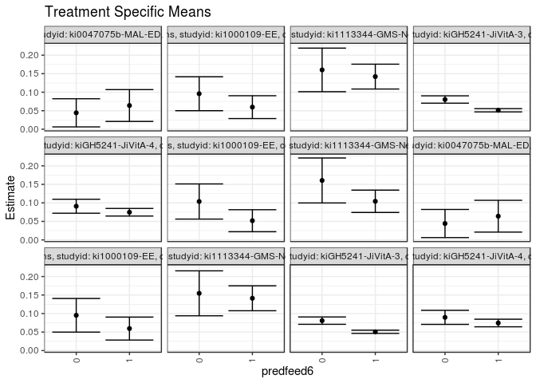

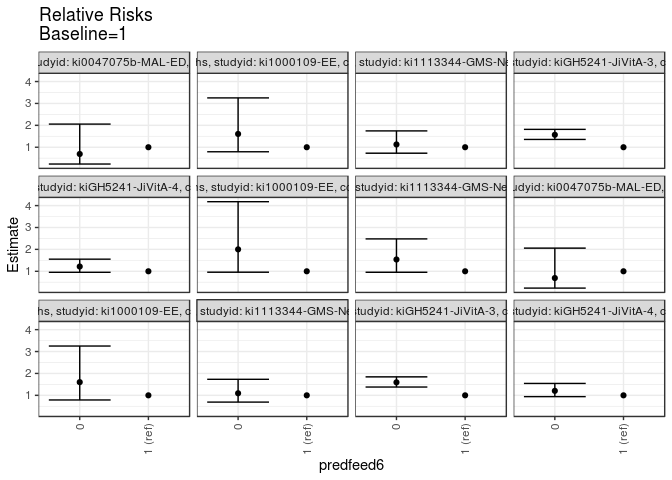

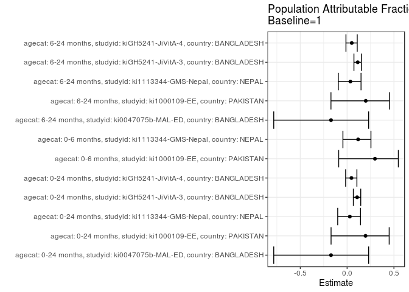

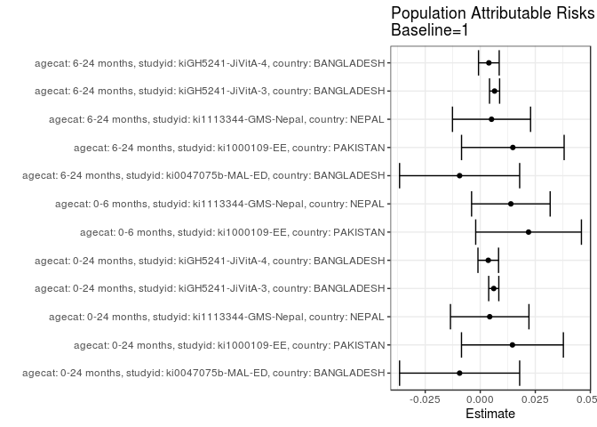

## Results Table

### Parameter: TSM

| agecat | studyid | country | intervention_level | baseline_level | estimate | ci_lower | ci_upper |
| --- | --- | --- | --- | --- | --- | --- | --- |
| 0-24 months | ki0047075b-MAL-ED | BANGLADESH | 1 | NA | 0.0640000 | 0.0210033 | 0.1069967 |
| 0-24 months | ki0047075b-MAL-ED | BANGLADESH | 0 | NA | 0.0442478 | 0.0062515 | 0.0822441 |
| 0-24 months | ki1000109-EE | PAKISTAN | 1 | NA | 0.0596561 | 0.0288178 | 0.0904945 |
| 0-24 months | ki1000109-EE | PAKISTAN | 0 | NA | 0.0958682 | 0.0500391 | 0.1416973 |
| 0-24 months | ki1113344-GMS-Nepal | NEPAL | 1 | NA | 0.1421397 | 0.1085841 | 0.1756953 |
| 0-24 months | ki1113344-GMS-Nepal | NEPAL | 0 | NA | 0.1601823 | 0.1013192 | 0.2190454 |
| 0-24 months | kiGH5241-JiVitA-3 | BANGLADESH | 1 | NA | 0.0511600 | 0.0467976 | 0.0555224 |
| 0-24 months | kiGH5241-JiVitA-3 | BANGLADESH | 0 | NA | 0.0802645 | 0.0703524 | 0.0901766 |
| 0-24 months | kiGH5241-JiVitA-4 | BANGLADESH | 1 | NA | 0.0747308 | 0.0644595 | 0.0850022 |
| 0-24 months | kiGH5241-JiVitA-4 | BANGLADESH | 0 | NA | 0.0909429 | 0.0720333 | 0.1098525 |
| 0-6 months | ki1000109-EE | PAKISTAN | 1 | NA | 0.0518339 | 0.0221271 | 0.0815407 |
| 0-6 months | ki1000109-EE | PAKISTAN | 0 | NA | 0.1037168 | 0.0562185 | 0.1512151 |
| 0-6 months | ki1113344-GMS-Nepal | NEPAL | 1 | NA | 0.1042974 | 0.0741334 | 0.1344614 |
| 0-6 months | ki1113344-GMS-Nepal | NEPAL | 0 | NA | 0.1605001 | 0.0997723 | 0.2212278 |
| 6-24 months | ki0047075b-MAL-ED | BANGLADESH | 1 | NA | 0.0640000 | 0.0210033 | 0.1069967 |
| 6-24 months | ki0047075b-MAL-ED | BANGLADESH | 0 | NA | 0.0442478 | 0.0062515 | 0.0822441 |
| 6-24 months | ki1000109-EE | PAKISTAN | 1 | NA | 0.0594716 | 0.0284924 | 0.0904507 |
| 6-24 months | ki1000109-EE | PAKISTAN | 0 | NA | 0.0952967 | 0.0498431 | 0.1407503 |
| 6-24 months | ki1113344-GMS-Nepal | NEPAL | 1 | NA | 0.1413100 | 0.1076839 | 0.1749360 |
| 6-24 months | ki1113344-GMS-Nepal | NEPAL | 0 | NA | 0.1546532 | 0.0939539 | 0.2153524 |
| 6-24 months | kiGH5241-JiVitA-3 | BANGLADESH | 1 | NA | 0.0507912 | 0.0464433 | 0.0551390 |
| 6-24 months | kiGH5241-JiVitA-3 | BANGLADESH | 0 | NA | 0.0809519 | 0.0710357 | 0.0908681 |
| 6-24 months | kiGH5241-JiVitA-4 | BANGLADESH | 1 | NA | 0.0744623 | 0.0642147 | 0.0847099 |
| 6-24 months | kiGH5241-JiVitA-4 | BANGLADESH | 0 | NA | 0.0897458 | 0.0707869 | 0.1087046 |

### Parameter: E(Y)

| agecat | studyid | country | intervention_level | baseline_level | estimate | ci_lower | ci_upper |
| --- | --- | --- | --- | --- | --- | --- | --- |
| 0-24 months | ki0047075b-MAL-ED | BANGLADESH | NA | NA | 0.0546218 | 0.0256911 | 0.0835526 |
| 0-24 months | ki1000109-EE | PAKISTAN | NA | NA | 0.0742706 | 0.0477670 | 0.1007741 |
| 0-24 months | ki1113344-GMS-Nepal | NEPAL | NA | NA | 0.1464286 | 0.1171213 | 0.1757358 |
| 0-24 months | kiGH5241-JiVitA-3 | BANGLADESH | NA | NA | 0.0572887 | 0.0532017 | 0.0613756 |
| 0-24 months | kiGH5241-JiVitA-4 | BANGLADESH | NA | NA | 0.0783679 | 0.0692461 | 0.0874896 |
| 0-6 months | ki1000109-EE | PAKISTAN | NA | NA | 0.0737705 | 0.0469540 | 0.1005870 |
| 0-6 months | ki1113344-GMS-Nepal | NEPAL | NA | NA | 0.1181989 | 0.0907652 | 0.1456326 |
| 6-24 months | ki0047075b-MAL-ED | BANGLADESH | NA | NA | 0.0546218 | 0.0256911 | 0.0835526 |
| 6-24 months | ki1000109-EE | PAKISTAN | NA | NA | 0.0742706 | 0.0477670 | 0.1007741 |
| 6-24 months | ki1113344-GMS-Nepal | NEPAL | NA | NA | 0.1464286 | 0.1171213 | 0.1757358 |
| 6-24 months | kiGH5241-JiVitA-3 | BANGLADESH | NA | NA | 0.0572887 | 0.0532017 | 0.0613756 |
| 6-24 months | kiGH5241-JiVitA-4 | BANGLADESH | NA | NA | 0.0783679 | 0.0692461 | 0.0874896 |

### Parameter: RR

| agecat | studyid | country | intervention_level | baseline_level | estimate | ci_lower | ci_upper |
| --- | --- | --- | --- | --- | --- | --- | --- |
| 0-24 months | ki0047075b-MAL-ED | BANGLADESH | 1 | 1 | 1.0000000 | 1.0000000 | 1.000000 |
| 0-24 months | ki0047075b-MAL-ED | BANGLADESH | 0 | 1 | 0.6913717 | 0.2323821 | 2.056934 |
| 0-24 months | ki1000109-EE | PAKISTAN | 1 | 1 | 1.0000000 | 1.0000000 | 1.000000 |
| 0-24 months | ki1000109-EE | PAKISTAN | 0 | 1 | 1.6070125 | 0.7937901 | 3.253365 |
| 0-24 months | ki1113344-GMS-Nepal | NEPAL | 1 | 1 | 1.0000000 | 1.0000000 | 1.000000 |
| 0-24 months | ki1113344-GMS-Nepal | NEPAL | 0 | 1 | 1.1269356 | 0.7274504 | 1.745801 |
| 0-24 months | kiGH5241-JiVitA-3 | BANGLADESH | 1 | 1 | 1.0000000 | 1.0000000 | 1.000000 |
| 0-24 months | kiGH5241-JiVitA-3 | BANGLADESH | 0 | 1 | 1.5688914 | 1.3558421 | 1.815418 |
| 0-24 months | kiGH5241-JiVitA-4 | BANGLADESH | 1 | 1 | 1.0000000 | 1.0000000 | 1.000000 |
| 0-24 months | kiGH5241-JiVitA-4 | BANGLADESH | 0 | 1 | 1.2169395 | 0.9530703 | 1.553864 |
| 0-6 months | ki1000109-EE | PAKISTAN | 1 | 1 | 1.0000000 | 1.0000000 | 1.000000 |
| 0-6 months | ki1000109-EE | PAKISTAN | 0 | 1 | 2.0009448 | 0.9581986 | 4.178445 |
| 0-6 months | ki1113344-GMS-Nepal | NEPAL | 1 | 1 | 1.0000000 | 1.0000000 | 1.000000 |
| 0-6 months | ki1113344-GMS-Nepal | NEPAL | 0 | 1 | 1.5388695 | 0.9550486 | 2.479580 |
| 6-24 months | ki0047075b-MAL-ED | BANGLADESH | 1 | 1 | 1.0000000 | 1.0000000 | 1.000000 |
| 6-24 months | ki0047075b-MAL-ED | BANGLADESH | 0 | 1 | 0.6913717 | 0.2323821 | 2.056934 |
| 6-24 months | ki1000109-EE | PAKISTAN | 1 | 1 | 1.0000000 | 1.0000000 | 1.000000 |
| 6-24 months | ki1000109-EE | PAKISTAN | 0 | 1 | 1.6023919 | 0.7895390 | 3.252100 |
| 6-24 months | ki1113344-GMS-Nepal | NEPAL | 1 | 1 | 1.0000000 | 1.0000000 | 1.000000 |
| 6-24 months | ki1113344-GMS-Nepal | NEPAL | 0 | 1 | 1.0944250 | 0.6913046 | 1.732617 |
| 6-24 months | kiGH5241-JiVitA-3 | BANGLADESH | 1 | 1 | 1.0000000 | 1.0000000 | 1.000000 |
| 6-24 months | kiGH5241-JiVitA-3 | BANGLADESH | 0 | 1 | 1.5938188 | 1.3781109 | 1.843290 |
| 6-24 months | kiGH5241-JiVitA-4 | BANGLADESH | 1 | 1 | 1.0000000 | 1.0000000 | 1.000000 |
| 6-24 months | kiGH5241-JiVitA-4 | BANGLADESH | 0 | 1 | 1.2052518 | 0.9410998 | 1.543547 |

### Parameter: PAR

| agecat | studyid | country | intervention_level | baseline_level | estimate | ci_lower | ci_upper |
| --- | --- | --- | --- | --- | --- | --- | --- |
| 0-24 months | ki0047075b-MAL-ED | BANGLADESH | 1 | NA | -0.0093782 | -0.0366504 | 0.0178941 |
| 0-24 months | ki1000109-EE | PAKISTAN | 1 | NA | 0.0146144 | -0.0085248 | 0.0377536 |
| 0-24 months | ki1113344-GMS-Nepal | NEPAL | 1 | NA | 0.0042889 | -0.0135350 | 0.0221128 |
| 0-24 months | kiGH5241-JiVitA-3 | BANGLADESH | 1 | NA | 0.0061287 | 0.0038329 | 0.0084245 |
| 0-24 months | kiGH5241-JiVitA-4 | BANGLADESH | 1 | NA | 0.0036370 | -0.0010443 | 0.0083184 |
| 0-6 months | ki1000109-EE | PAKISTAN | 1 | NA | 0.0219366 | -0.0020716 | 0.0459447 |
| 0-6 months | ki1113344-GMS-Nepal | NEPAL | 1 | NA | 0.0139015 | -0.0039456 | 0.0317486 |
| 6-24 months | ki0047075b-MAL-ED | BANGLADESH | 1 | NA | -0.0093782 | -0.0366504 | 0.0178941 |
| 6-24 months | ki1000109-EE | PAKISTAN | 1 | NA | 0.0147990 | -0.0085005 | 0.0380985 |
| 6-24 months | ki1113344-GMS-Nepal | NEPAL | 1 | NA | 0.0051186 | -0.0126174 | 0.0228546 |
| 6-24 months | kiGH5241-JiVitA-3 | BANGLADESH | 1 | NA | 0.0064975 | 0.0042054 | 0.0087896 |
| 6-24 months | kiGH5241-JiVitA-4 | BANGLADESH | 1 | NA | 0.0039056 | -0.0007924 | 0.0086036 |

### Parameter: PAF

| agecat | studyid | country | intervention_level | baseline_level | estimate | ci_lower | ci_upper |
| --- | --- | --- | --- | --- | --- | --- | --- |
| 0-24 months | ki0047075b-MAL-ED | BANGLADESH | 1 | NA | -0.1716923 | -0.7832238 | 0.2301231 |
| 0-24 months | ki1000109-EE | PAKISTAN | 1 | NA | 0.1967726 | -0.1711851 | 0.4491270 |
| 0-24 months | ki1113344-GMS-Nepal | NEPAL | 1 | NA | 0.0292898 | -0.1002335 | 0.1435652 |
| 0-24 months | kiGH5241-JiVitA-3 | BANGLADESH | 1 | NA | 0.1069788 | 0.0664862 | 0.1457150 |
| 0-24 months | kiGH5241-JiVitA-4 | BANGLADESH | 1 | NA | 0.0464099 | -0.0155211 | 0.1045641 |
| 0-6 months | ki1000109-EE | PAKISTAN | 1 | NA | 0.2973623 | -0.0896079 | 0.5469015 |
| 0-6 months | ki1113344-GMS-Nepal | NEPAL | 1 | NA | 0.1176111 | -0.0446496 | 0.2546685 |
| 6-24 months | ki0047075b-MAL-ED | BANGLADESH | 1 | NA | -0.1716923 | -0.7832238 | 0.2301231 |
| 6-24 months | ki1000109-EE | PAKISTAN | 1 | NA | 0.1992579 | -0.1722727 | 0.4530387 |
| 6-24 months | ki1113344-GMS-Nepal | NEPAL | 1 | NA | 0.0349564 | -0.0939997 | 0.1487117 |
| 6-24 months | kiGH5241-JiVitA-3 | BANGLADESH | 1 | NA | 0.1134169 | 0.0730181 | 0.1520551 |
| 6-24 months | kiGH5241-JiVitA-4 | BANGLADESH | 1 | NA | 0.0498367 | -0.0123217 | 0.1081784 |